# Презентация по лабораторной работе №14

Дисциплина: Имитационное моделирование

Лобанова П.И.

Российский университет дружбы народов, Москва, Россия

5 мая 2025

# Информация

## Докладчик

- Лобанова Полина Иннокентьевна
- Учащаяся на направлении “Фундаментальная информатика и информационные технологии”
- Студентка группы НФИбд-02-22
- polla-2004@mail.ru

# Цель

Реализовать модель оформления заказов клиентов одним оператором, модель обслуживания двух типов заказов от клиентов в интернет-магазине и модель оформления заказов несколькими операторами.

# Задание 1

1. В интернет-магазине заказы принимает один оператор. Интервалы поступления заказов распределены равномерно с интервалом 15 ± 4 мин. Время оформления заказа также распределено равномерно на интервале 10 ± 2 мин. Обработка поступивших заказов происходит в порядке очереди (FIFO). Требуется разработать модель обработки заказов в течение 8 часов.
2. Скорректируйте модель в соответствии с изменениями входных данных: интервалы поступления заказов распределены равномерно с интервалом 3.14 ± 1.7 мин; время оформления заказа также распределено равномерно на интервале 6.66 ± 1.7 мин. Проанализируйте отчёт, сравнив результаты с результатами предыдущего моделирования.
3. Проанализируйте отчёт и гистограмму по результатам моделирования.

# Выполнение

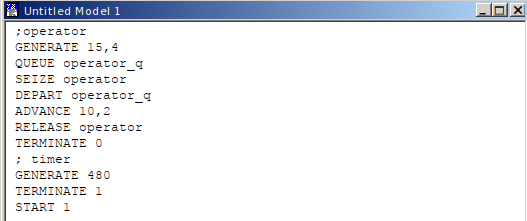

*Модель оформления заказов клиентов одним оператором*

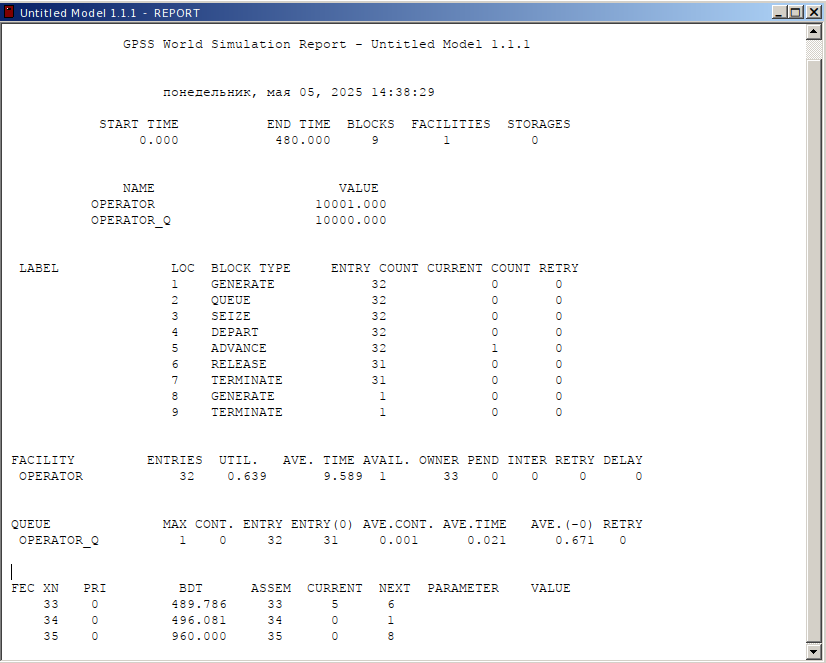

*Отчёт по модели оформления заказов в интернет-магазине*

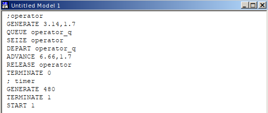

*Модель оформления заказов клиентов одним оператором с измененным временем*

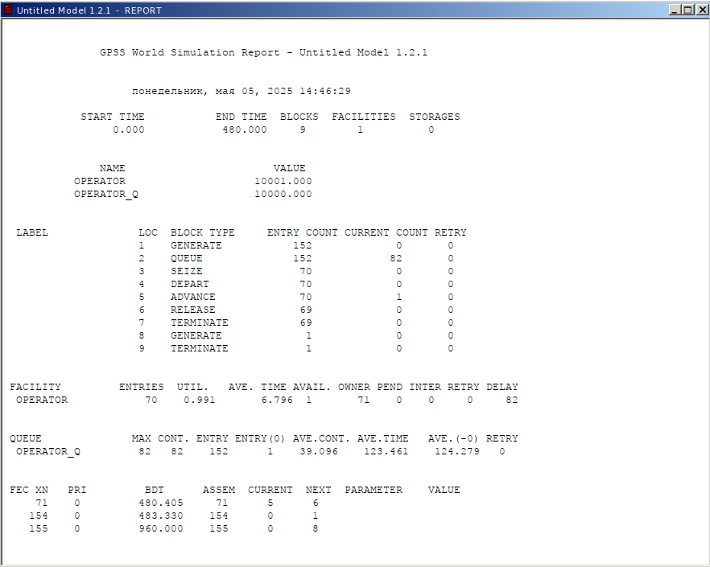

*Отчёт по модели оформления заказов в интернет-магазине с измененным временем*

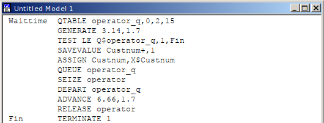

*Построение гистограммы распределения заявок в очереди*

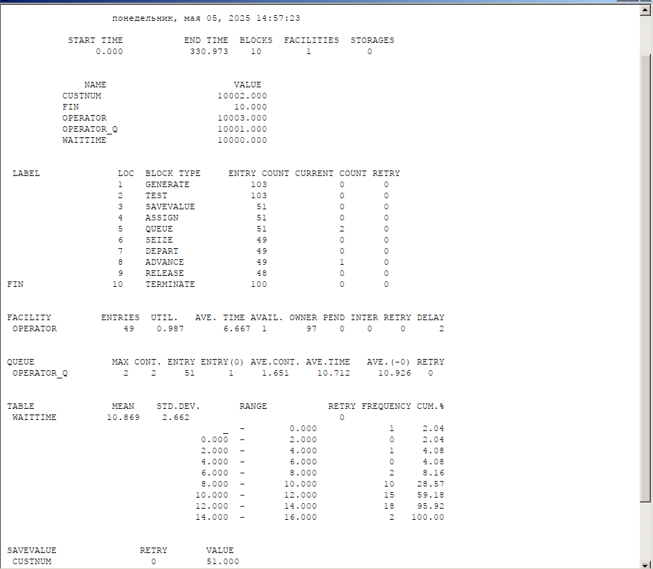

*Отчет по построению гистограммы распределения заявок в очереди*

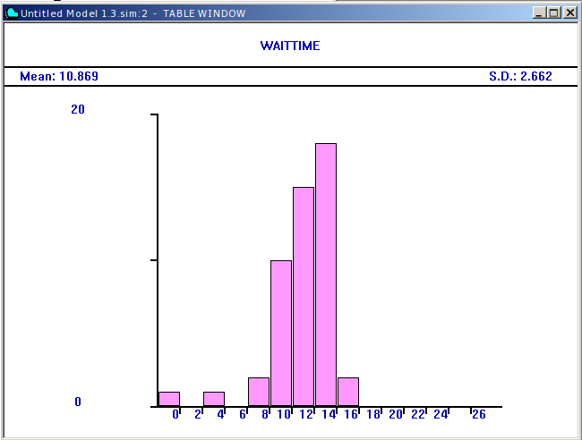

*Гистограмма распределения заявок в очереди*

# Задание 2

1. В интернет-магазин к одному оператору поступают два типа заявок от клиентов — обычный заказ и заказ с оформление дополнительного пакета услуг. Заявки первого типа поступают каждые 15 ± 4 мин. Заявки второго типа — каждые 30 ± 8 мин. Оператор обрабатывает заявки по принципу FIFO («первым пришел — первым обслужился»). Время, затраченное на оформление обычного заказа, составляет 10 ± 2 мин, а на оформление дополнительного пакета услуг — 5 ± 2 мин. Требуется разработать модель обработки заказов в течение 8 часов, обеспечив сбор данных об очереди заявок от клиентов.
2. Скорректируйте модель так, чтобы учитывалось условие, что число заказов с дополнительным пакетом услуг составляет 30% от общего числа заказов. Используйте оператор TRANSFER. Проанализируйте отчёт.

# Выполнение

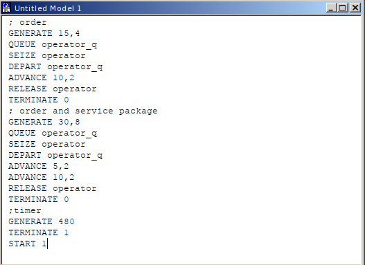

*Модель обслуживания двух типов заказов от клиентов в интернет-магазине*

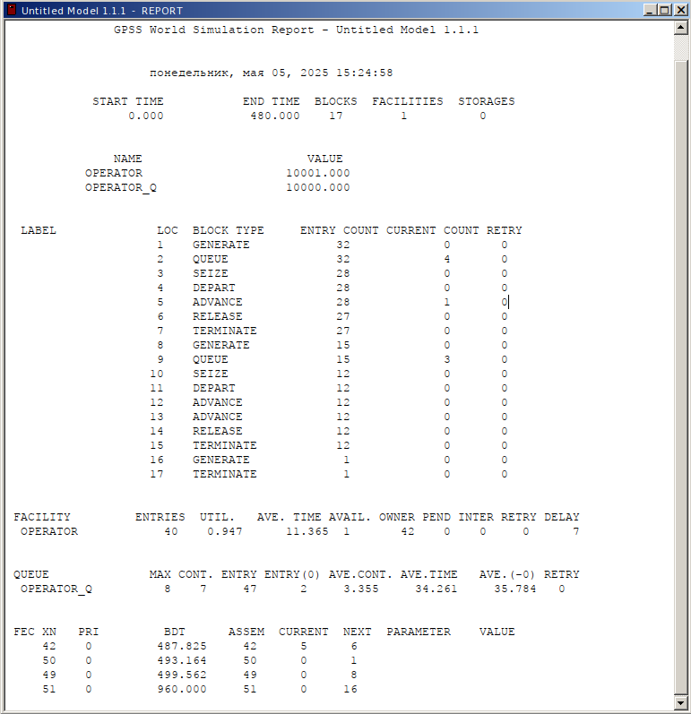

*Отчёт по модели оформления заказов двух типов*

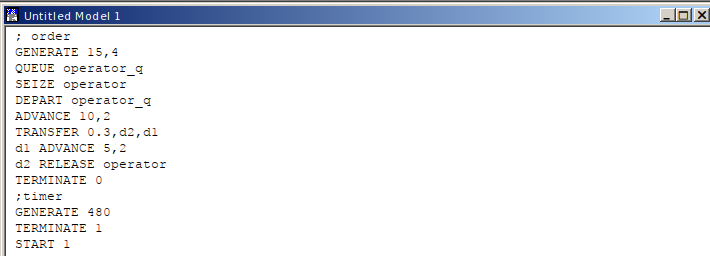

*Модель обслуживания двух типов заказов от клиентов в интернет-магазине с учетом, что число заказов с дополнительным пакетом услуг составляет 30% от общего числа заказов.*

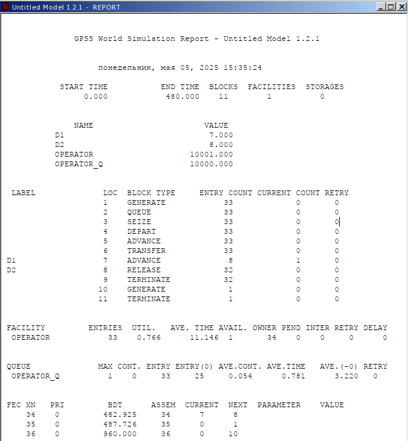

*Отчёт по модели оформления заказов двух типов с учетом, что число заказов с дополнительным пакетом услуг составляет 30% от общего числа заказов.*

# Задание 3

1. В интернет-магазине заказы принимают 4 оператора. Интервалы поступления заказов распределены равномерно с интервалом 5 ± 2 мин. Время оформления заказа каждым оператором также распределено равномерно на интервале 10 ± 2 мин. Обработка поступивших заказов происходит в порядке очереди (FIFO). Требуется определить характеристики очереди заявок на оформление заказов при условии, что заявка может обрабатываться одним из 4-х операторов в течение восьмичасового рабочего дня.
2. Измените модель: требуется учесть в ней возможные отказы клиентов от заказа — когда при подаче заявки на заказ клиент видит в очереди более двух других заявок, он отказывается от подачи заявки, то есть отказывается от обслуживания (используйте блок TEST и стандартный числовой атрибут Qj текущей длины очереди j). Проанализируйте отчёт изменённой модели.

# Выполнение

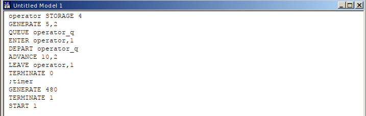

*Модель оформления заказов несколькими операторами.*

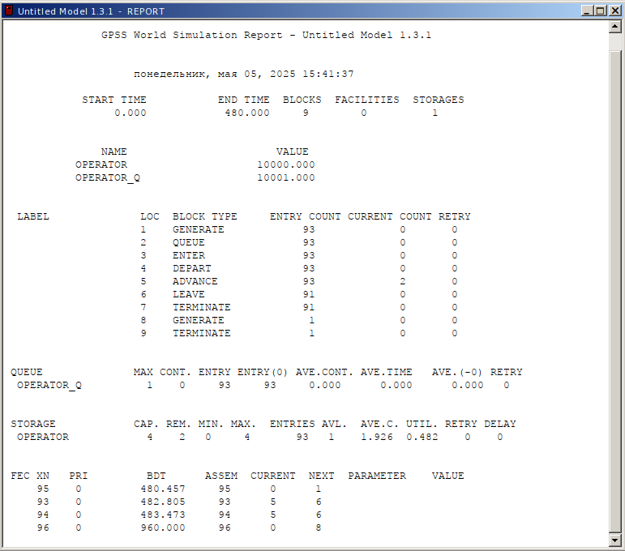

*Отчёт по модели оформления заказов несколькими операторами.*

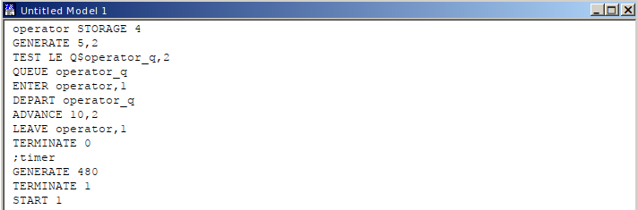

*Модель оформления заказов несколькими операторами с учетом возможных отказов клиентов.*

[figure not shown]

*Отчёт по модели оформления заказов несколькими операторами с учетом возможных отказов клиентов.*

# Вывод

Я реализовала модель оформления заказов клиентов одним оператором, модель обслуживания двух типов заказов от клиентов в интернет-магазине и модель оформления заказов несколькими операторами.